# EDA — `02_clinical` (RISA_DATA_V1.0)

**HealthSignal LATAM · Hackathon Perú 2026**

Este notebook explora las 4 tablas clínicas de RISA: `medications` (catálogo), `conditions` (antecedentes), `medication_administrations` (administración real de fármacos) y `laboratory_results` (resultados de laboratorio).

A diferencia de `01_master` (limpio por diseño), en esta capa **sí es donde el reto empieza a meter imperfecciones reales**: formatos de fecha/hora heterogéneos, cobertura desigual entre pacientes, valores fuera de rango de referencia, etc. El objetivo aquí es documentar esas imperfecciones con evidencia cuantitativa — porque son justamente la clase de problema que el prototipo de HealthSignal tiene que manejar explícitamente (no solo "ignorar los nulos").

```python
import pandas as pd
import numpy as np
import matplotlib.pyplot as plt
import seaborn as sns

pd.set_option('display.max_columns', 50)
pd.set_option('display.width', 160)
sns.set_theme(style='whitegrid', palette='Set2')
plt.rcParams['figure.dpi'] = 110

MASTER_DIR = "../data/raw/01_master"
DATA_DIR   = "../data/raw/02_clinical"

patients   = pd.read_csv(f"{MASTER_DIR}/patients.csv")
encounters = pd.read_csv(f"{MASTER_DIR}/encounters.csv")

medications  = pd.read_csv(f"{DATA_DIR}/medications.csv")
conditions   = pd.read_csv(f"{DATA_DIR}/conditions.csv")
admin        = pd.read_csv(f"{DATA_DIR}/medication_administrations.csv")
labs         = pd.read_csv(f"{DATA_DIR}/laboratory_results.csv")

for name, df in [("medications", medications), ("conditions", conditions),
                  ("medication_administrations", admin), ("laboratory_results", labs)]:
    print(f"{name:28s} -> {df.shape[0]:5d} filas x {df.shape[1]} columnas")
```

```
medications                  ->     5 filas x 4 columnas
conditions                   ->  1484 filas x 8 columnas
medication_administrations   ->   856 filas x 10 columnas
laboratory_results           ->  4593 filas x 14 columnas
```

## 1. `medications` — catálogo (tabla de referencia)

Solo 5 filas: es el catálogo de clases de medicamento usado por `medication_administrations`.

```python
medications
```

|  | medication_id | medication_class | generic_category | administration_route |
| --- | --- | --- | --- | --- |
| 0 | MED-001 | RATE_MODIFYING | CARDIOVASCULAR_SUPPORT | ORAL |
| 1 | MED-002 | RESPIRATORY_SUPPORT | RESPIRATORY_SUPPORT | INHALED |
| 2 | MED-003 | ANTIPYRETIC_CLASS | SYMPTOM_SUPPORT | ORAL |
| 3 | MED-004 | FLUID_SUPPORT | GENERAL_SUPPORT | IV |
| 4 | MED-005 | METABOLIC_SUPPORT | METABOLIC_SUPPORT | ORAL |

## 2. `conditions` — antecedentes clínicos

1484 registros de antecedente para 1000 pacientes (cada paciente tiene entre 1 y 3).

```python
print(conditions.dtypes)
conditions.head()
```

```
condition_id          str
patient_id            str
condition_category    str
onset_date            str
status                str
severity_context      str
source_system         str
recorded_datetime     str
dtype: object
```

|  | condition_id | patient_id | condition_category | onset_date | status | severity_context | source_system | recorded_datetime |
| --- | --- | --- | --- | --- | --- | --- | --- | --- |
| 0 | COND-000001 | PAT-0001 | RENAL_HISTORY | 2025-02-16 | ACTIVE | CONTEXT_ONLY | EHR_CORE | 2026-06-17 00:00:00 |
| 1 | COND-000002 | PAT-0001 | CARDIOVASCULAR_HISTORY | 2023-01-27 | ACTIVE | CONTEXT_ONLY | EHR_CORE | 2026-01-23 00:00:00 |
| 2 | COND-000003 | PAT-0002 | CARDIOVASCULAR_HISTORY | 2024-11-19 | ACTIVE | CONTEXT_ONLY | EHR_CORE | 2025-12-13 00:00:00 |
| 3 | COND-000004 | PAT-0002 | NO_MAJOR_RECORDED_HISTORY | 2024-10-27 | RECORDED | CONTEXT_ONLY | EHR_CORE | 2026-03-29 00:00:00 |
| 4 | COND-000005 | PAT-0003 | RESPIRATORY_HISTORY | 2025-11-29 | ACTIVE | CONTEXT_ONLY | EHR_CORE | 2026-02-13 00:00:00 |

```python
print("Nulos por columna:")
print(conditions.isnull().sum())
print("\nDuplicados exactos:", conditions.duplicated().sum())
print("condition_id únicos:", conditions['condition_id'].nunique(), "/", len(conditions))
print("\npatient_id de conditions no está en patients:",
      (~conditions['patient_id'].isin(patients['patient_id'])).sum())
print("Pacientes sin ningún antecedente registrado:",
      1000 - conditions['patient_id'].nunique())
```

```
Nulos por columna:
condition_id          0
patient_id            0
condition_category    0
onset_date            0
status                0
severity_context      0
source_system         0
recorded_datetime     0
dtype: int64

Duplicados exactos: 0
condition_id únicos: 1484 / 1484

patient_id de conditions no está en patients: 0
Pacientes sin ningún antecedente registrado: 0
```

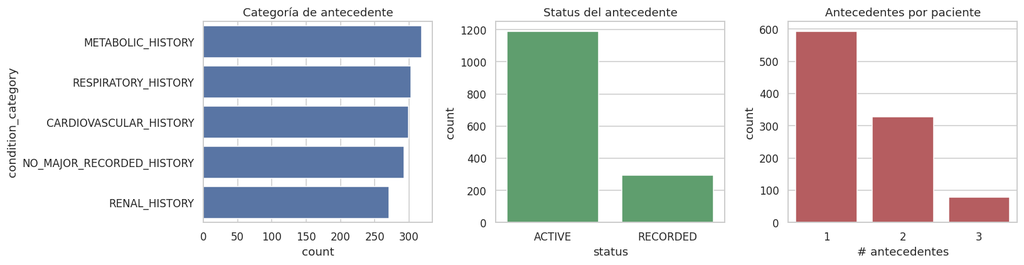

```python
fig, axes = plt.subplots(1, 3, figsize=(15, 4))

sns.countplot(data=conditions, y='condition_category',
              order=conditions['condition_category'].value_counts().index, ax=axes[0], color='#4C72B0')
axes[0].set_title('Categoría de antecedente')

sns.countplot(data=conditions, x='status', ax=axes[1], color='#55A868')
axes[1].set_title('Status del antecedente')

sns.countplot(data=conditions.groupby('patient_id').size().reset_index(name='n'), x='n',
              ax=axes[2], color='#C44E52')
axes[2].set_title('Antecedentes por paciente')
axes[2].set_xlabel('# antecedentes')

plt.tight_layout()
plt.show()
```

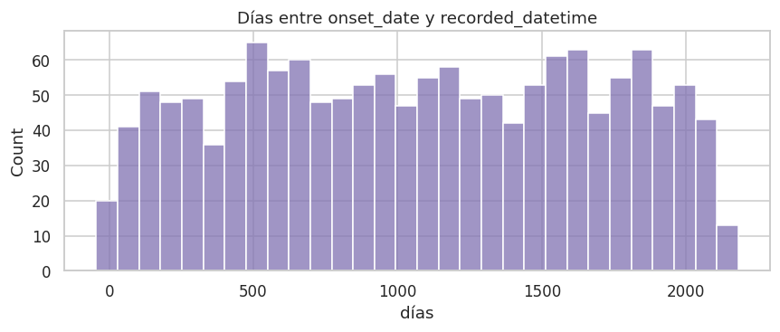

```
count    1484.000000
mean     1074.381402
std       603.537173
min       -45.000000
25%       555.750000
50%      1082.500000
75%      1600.000000
max      2181.000000
dtype: float64
Antecedentes con recorded_datetime ANTES de onset_date (anomalía): 8
```

```python
conditions['onset_date'] = pd.to_datetime(conditions['onset_date'])
conditions['recorded_datetime'] = pd.to_datetime(conditions['recorded_datetime'])
gap_days = (conditions['recorded_datetime'] - conditions['onset_date']).dt.days

plt.figure(figsize=(8, 3.5))
sns.histplot(gap_days, bins=30, color='#8172B2')
plt.title('Días entre onset_date y recorded_datetime')
plt.xlabel('días')
plt.tight_layout()
plt.show()
print(gap_days.describe())
print("Antecedentes con recorded_datetime ANTES de onset_date (anomalía):", (gap_days < 0).sum())
```

## 3. `medication_administrations` — administración real de fármacos

856 registros. **Solo 618 de los 1000 pacientes (61.8%) tienen alguna administración registrada** — a diferencia de `01_master`, aquí la cobertura ya no es uniforme, y eso es esperable (no todos los pacientes reciben medicación durante su episodio).

```python
print(admin.dtypes)
admin.head()
```

```
administration_id          str
patient_id                 str
encounter_id               str
medication_id              str
start_datetime             str
end_datetime               str
dose_value               int64
dose_unit                  str
administration_status      str
source_system              str
dtype: object
```

|  | administration_id | patient_id | encounter_id | medication_id | start_datetime | end_datetime | dose_value | dose_unit | administration_status | source_system |
| --- | --- | --- | --- | --- | --- | --- | --- | --- | --- | --- |
| 0 | ADM-000001 | PAT-0001 | ENC-000001 | MED-003 | 2026-07-13 03:09:57.374250 | 2026-07-13 07:09:57.374250 | 2 | synthetic_unit | COMPLETED | EHR_MED |
| 1 | ADM-000002 | PAT-0002 | ENC-000002 | MED-005 | 2026-07-16 05:21:27.377397 | 2026-07-16 13:21:27.377397 | 10 | synthetic_unit | COMPLETED | EHR_MED |
| 2 | ADM-000003 | PAT-0002 | ENC-000002 | MED-005 | 2026-07-15 02:53:07.182118 | 2026-07-15 08:53:07.182118 | 2 | synthetic_unit | COMPLETED | EHR_MED |
| 3 | ADM-000004 | PAT-0003 | ENC-000003 | MED-004 | 2026-07-13 11:13:27.220798 | 2026-07-13 15:13:27.220798 | 2 | synthetic_unit | COMPLETED | EHR_MED |
| 4 | ADM-000005 | PAT-0005 | ENC-000005 | MED-001 | 2026-07-15 05:10:00.823083 | 2026-07-15 11:10:00.823083 | 10 | synthetic_unit | COMPLETED | EHR_MED |

```python
print("Nulos por columna:")
print(admin.isnull().sum())
print("\nDuplicados exactos:", admin.duplicated().sum())
print("administration_id únicos:", admin['administration_id'].nunique(), "/", len(admin))

print("\n--- Integridad referencial ---")
print("patient_id no está en patients:", (~admin['patient_id'].isin(patients['patient_id'])).sum())
print("encounter_id no está en encounters:", (~admin['encounter_id'].isin(encounters['encounter_id'])).sum())
print("medication_id no está en medications:", (~admin['medication_id'].isin(medications['medication_id'])).sum())
print("\nCobertura de pacientes con >=1 administración:", admin['patient_id'].nunique(), "/ 1000")
```

```
Nulos por columna:
administration_id        0
patient_id               0
encounter_id             0
medication_id            0
start_datetime           0
end_datetime             0
dose_value               0
dose_unit                0
administration_status    0
source_system            0
dtype: int64

Duplicados exactos: 0
administration_id únicos: 856 / 856

--- Integridad referencial ---
patient_id no está en patients: 0
encounter_id no está en encounters: 0
medication_id no está en medications: 0

Cobertura de pacientes con >=1 administración: 618 / 1000
```

### 3.1 Hallazgo de calidad de datos: formato de timestamp heterogéneo

Antes de parsear las fechas a `datetime`, vale la pena comprobar si todas siguen el mismo formato. En un dataset "de verdad" (no un CSV de juguete) es común que distintas fuentes escriban timestamps con distinta precisión.

```python
has_micro_start = admin['start_datetime'].str.contains(r'\.').sum()
has_micro_end   = admin['end_datetime'].str.contains(r'\.').sum()
print(f"start_datetime CON microsegundos: {has_micro_start} / {len(admin)}")
print(f"start_datetime SIN microsegundos: {len(admin)-has_micro_start} / {len(admin)}")
print(f"end_datetime   CON microsegundos: {has_micro_end} / {len(admin)}")

# pd.to_datetime con formato fijo falla aquí -> hay que usar format='mixed'
try:
    pd.to_datetime(admin['start_datetime'], format="%Y-%m-%d %H:%M:%S.%f")
except ValueError as e:
    print("\nFalla con formato fijo (esperado):")
    print(e)
```

```
start_datetime CON microsegundos: 811 / 856
start_datetime SIN microsegundos: 45 / 856
end_datetime   CON microsegundos: 811 / 856

Falla con formato fijo (esperado):
time data "2026-07-17 18:20:00" doesn't match format "%Y-%m-%d %H:%M:%S.%f". You might want to try:
    - passing `format` if your strings have a consistent format;
    - passing `format='ISO8601'` if your strings are all ISO8601 but not necessarily in exactly the same format;
    - passing `format='mixed'`, and the format will be inferred for each element individually. You might want to use `dayfirst` alongside this.
```

**Esto confirma el hallazgo:** ~5% de los registros (45/856) llegan con timestamps sin microsegundos, mezclados con el 95% que sí los trae — probablemente porque provienen de un sistema de origen distinto (`source_system`) o de una ruta de captura menos granular. Un parser ingenuo con formato fijo **rompe** al toparse con esta mezcla; el pipeline de integración debe usar parsing flexible (`format='mixed'` o inferencia por fila) en vez de asumir un único formato.

```python
admin['start_datetime'] = pd.to_datetime(admin['start_datetime'], format='mixed')
admin['end_datetime']   = pd.to_datetime(admin['end_datetime'], format='mixed')

dur_h = (admin['end_datetime'] - admin['start_datetime']).dt.total_seconds() / 3600
print("Duración de administración (horas) — describe:")
print(dur_h.describe())
print("\nend_datetime < start_datetime (anomalía):", (admin['end_datetime'] < admin['start_datetime']).sum())
```

```
Duración de administración (horas) — describe:
count    856.000000
mean       5.021028
std        2.235184
min        2.000000
25%        4.000000
50%        4.000000
75%        8.000000
max        8.000000
dtype: float64

end_datetime < start_datetime (anomalía): 0
```

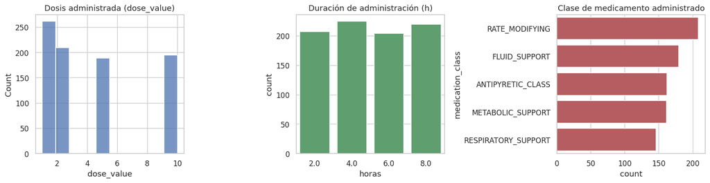

```python
fig, axes = plt.subplots(1, 3, figsize=(15, 4))

sns.histplot(admin['dose_value'], bins=10, ax=axes[0], color='#4C72B0')
axes[0].set_title('Dosis administrada (dose_value)')

sns.countplot(x=dur_h, ax=axes[1], color='#55A868')
axes[1].set_title('Duración de administración (h)')
axes[1].set_xlabel('horas')

admin_class = admin.merge(medications, on='medication_id')
sns.countplot(data=admin_class, y='medication_class',
              order=admin_class['medication_class'].value_counts().index, ax=axes[2], color='#C44E52')
axes[2].set_title('Clase de medicamento administrado')

plt.tight_layout()
plt.show()
```

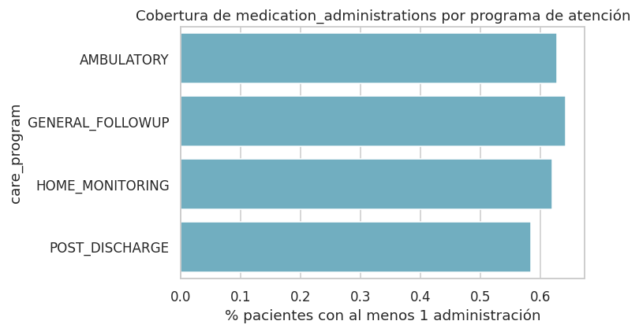

```python
admin_per_patient = admin.groupby('patient_id').size().reindex(patients['patient_id'], fill_value=0)
coverage = patients.assign(has_admin=(admin_per_patient.values > 0))
plt.figure(figsize=(7, 4))
sns.barplot(data=coverage.groupby('care_program')['has_admin'].mean().reset_index(),
            x='has_admin', y='care_program', color='#64B5CD')
plt.xlabel('% pacientes con al menos 1 administración')
plt.title('Cobertura de medication_administrations por programa de atención')
plt.tight_layout()
plt.show()
```

## 4. `laboratory_results` — resultados de laboratorio

4593 resultados para los 1000 pacientes (entre 2 y 9 por paciente) — la tabla clínica con más volumen y la que más señal aporta para detección de riesgo antes de llegar a `03_monitoring`.

```python
print(labs.dtypes)
labs.head()
```

```
lab_result_id          str
patient_id             str
encounter_id           str
test_code              str
test_name              str
result_value       float64
unit                   str
reference_low      float64
reference_high     float64
sample_datetime        str
result_datetime        str
facility_id            str
source_system          str
quality_flag           str
dtype: object
```

|  | lab_result_id | patient_id | encounter_id | test_code | test_name | result_value | unit | reference_low | reference_high | sample_datetime | result_datetime | facility_id | source_system | quality_flag |
| --- | --- | --- | --- | --- | --- | --- | --- | --- | --- | --- | --- | --- | --- | --- |
| 0 | LABR-00000001 | PAT-0001 | ENC-000001 | LAB_B | Synthetic laboratory marker B | 92.580 | uB | 70.0 | 110.0 | 2026-07-16 00:44:56.969159 | 2026-07-16 02:47:56.969159 | FAC-06 | LAB_SYS_A | OK |
| 1 | LABR-00000002 | PAT-0001 | ENC-000001 | LAB_C | Synthetic laboratory marker C | 1.234 | uC | 0.5 | 2.0 | 2026-07-16 00:44:56.969159 | 2026-07-16 02:31:56.969159 | FAC-06 | LAB_SYS_A | OK |
| 2 | LABR-00000003 | PAT-0002 | ENC-000002 | LAB_B | Synthetic laboratory marker B | 81.437 | uB | 70.0 | 110.0 | 2026-07-19 01:58:24.263554 | 2026-07-19 02:29:24.263554 | FAC-06 | LAB_SYS_A | OK |
| 3 | LABR-00000004 | PAT-0002 | ENC-000002 | LAB_A | Synthetic laboratory marker A | 3.730 | uA | 0.0 | 10.0 | 2026-07-19 01:58:24.263554 | 2026-07-19 03:24:24.263554 | FAC-06 | LAB_SYS_A | OK |
| 4 | LABR-00000005 | PAT-0002 | ENC-000002 | LAB_D | Synthetic laboratory marker D | 0.969 | uD | 0.5 | 1.3 | 2026-07-19 01:58:24.263554 | 2026-07-19 07:08:24.263554 | FAC-06 | LAB_SYS_B | OK |

```python
print("Nulos por columna:")
print(labs.isnull().sum())
print("\nDuplicados exactos:", labs.duplicated().sum())
print("lab_result_id únicos:", labs['lab_result_id'].nunique(), "/", len(labs))
dup_key = labs.duplicated(subset=['patient_id','test_code','sample_datetime']).sum()
print("Duplicados por (patient_id, test_code, sample_datetime):", dup_key)

print("\n--- Integridad referencial ---")
print("patient_id no está en patients:", (~labs['patient_id'].isin(patients['patient_id'])).sum())
print("encounter_id no está en encounters:", (~labs['encounter_id'].isin(encounters['encounter_id'])).sum())
print("facility_id:", labs['facility_id'].unique(), "-> todos los labs vienen de la red de laboratorios (FAC-06)")
print("\nquality_flag:")
print(labs['quality_flag'].value_counts())
```

```
Nulos por columna:
lab_result_id      0
patient_id         0
encounter_id       0
test_code          0
test_name          0
result_value       0
unit               0
reference_low      0
reference_high     0
sample_datetime    0
result_datetime    0
facility_id        0
source_system      0
quality_flag       0
dtype: int64

Duplicados exactos: 0
lab_result_id únicos: 4593 / 4593
Duplicados por (patient_id, test_code, sample_datetime): 0

--- Integridad referencial ---
patient_id no está en patients: 0
encounter_id no está en encounters: 0
facility_id: <StringArray>
['FAC-06']
Length: 1, dtype: str -> todos los labs vienen de la red de laboratorios (FAC-06)

quality_flag:
quality_flag
OK    4593
Name: count, dtype: int64
```

```python
has_micro_s = labs['sample_datetime'].str.contains(r'\.').sum()
has_micro_r = labs['result_datetime'].str.contains(r'\.').sum()
print(f"sample_datetime CON microsegundos: {has_micro_s} / {len(labs)}")
print(f"result_datetime CON microsegundos: {has_micro_r} / {len(labs)}")
print("-> misma heterogeneidad de formato que en medication_administrations; se repite el patrón "
      "'mismo campo, dos formatos', probablemente por mezcla de fuentes (source_system).")

labs['sample_datetime'] = pd.to_datetime(labs['sample_datetime'], format='mixed')
labs['result_datetime'] = pd.to_datetime(labs['result_datetime'], format='mixed')
```

```
sample_datetime CON microsegundos: 4541 / 4593
result_datetime CON microsegundos: 4541 / 4593
-> misma heterogeneidad de formato que en medication_administrations; se repite el patrón 'mismo campo, dos formatos', probablemente por mezcla de fuentes (source_system).
```

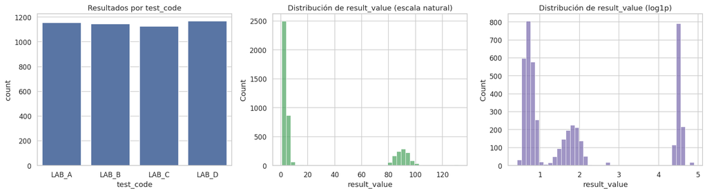

```
count    4593.000000
mean       24.427084
std        38.367349
min         0.523000
25%         1.027000
50%         2.464000
75%        14.200000
max       132.000000
Name: result_value, dtype: float64
```

```python
fig, axes = plt.subplots(1, 3, figsize=(16, 4.5))

sns.countplot(data=labs, x='test_code', order=sorted(labs['test_code'].unique()), ax=axes[0], color='#4C72B0')
axes[0].set_title('Resultados por test_code')

sns.histplot(labs['result_value'], bins=40, ax=axes[1], color='#55A868')
axes[1].set_title('Distribución de result_value (escala natural)')

sns.histplot(np.log1p(labs['result_value']), bins=40, ax=axes[2], color='#8172B2')
axes[2].set_title('Distribución de result_value (log1p)')

plt.tight_layout()
plt.show()
print(labs['result_value'].describe())
```

**Comentario:** `result_value` mezcla varios marcadores (`LAB_A`..`LAB_D`) con escalas y unidades distintas — la distribución "en escala natural" no es directamente interpretable sin normalizar por marcador. Para eso sirve el rango de referencia (`reference_low`/`reference_high`) de cada fila: es más informativo mirar cuánto se desvía cada resultado de SU PROPIO rango.

```
Resultados fuera de rango de referencia: 52 / 4593 (1.1%)
test_code
LAB_A    18
LAB_B    18
LAB_C    16
Name: count, dtype: int64
```

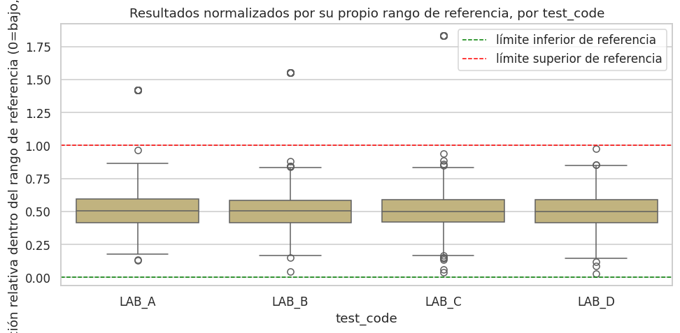

```python
labs['pct_of_range'] = (labs['result_value'] - labs['reference_low']) / (labs['reference_high'] - labs['reference_low'])
out_of_range = (labs['result_value'] < labs['reference_low']) | (labs['result_value'] > labs['reference_high'])
print(f"Resultados fuera de rango de referencia: {out_of_range.sum()} / {len(labs)} ({out_of_range.mean()*100:.1f}%)")
print(labs.loc[out_of_range, 'test_code'].value_counts())

plt.figure(figsize=(9, 4.5))
sns.boxplot(data=labs, x='test_code', y='pct_of_range', order=sorted(labs['test_code'].unique()), color='#CCB974')
plt.axhline(0, color='green', ls='--', lw=1, label='límite inferior de referencia')
plt.axhline(1, color='red', ls='--', lw=1, label='límite superior de referencia')
plt.ylabel('posición relativa dentro del rango de referencia (0=bajo, 1=alto)')
plt.title('Resultados normalizados por su propio rango de referencia, por test_code')
plt.legend()
plt.tight_layout()
plt.show()
```

**Comentario clave:** ~1.1% de los resultados caen fuera del rango de referencia — no es un porcentaje trivial dado el tamaño de la cohorte, y son candidatos naturales a alimentar el motor de señales de riesgo. El boxplot normalizado muestra que estos "fuera de rango" no están concentrados en un solo marcador, así que **no basta un único umbral global**: cada `test_code` necesita su propia lógica de referencia (justo lo que ya trae el dataset en `reference_low`/`high`).

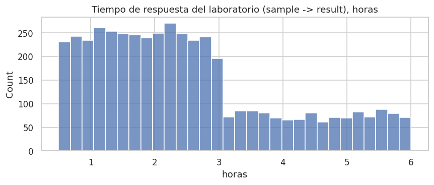

```
count    4593.000000
mean        2.483192
std         1.434290
min         0.500000
25%         1.350000
50%         2.216667
75%         3.166667
max         6.000000
dtype: float64
Turnaround negativo (resultado antes de la muestra, anomalía): 0
```

```python
tat_h = (labs['result_datetime'] - labs['sample_datetime']).dt.total_seconds() / 3600
plt.figure(figsize=(8, 3.5))
sns.histplot(tat_h, bins=30, color='#4C72B0')
plt.title('Tiempo de respuesta del laboratorio (sample -> result), horas')
plt.xlabel('horas')
plt.tight_layout()
plt.show()
print(tat_h.describe())
print("Turnaround negativo (resultado antes de la muestra, anomalía):", (tat_h < 0).sum())
```

**Comentario:** el turnaround de laboratorio (0.5 a 6 h) es razonable y sin anomalías de orden temporal — pero sí es un retraso real que hay que respetar al alinear labs con signos vitales/wearables en el análisis temporal: un resultado de laboratorio "pertenece" al momento de la toma de muestra, no al momento en que aparece en el sistema.

**Siguiente paso sugerido:** al construir el pipeline de integración, normalizar el parsing de timestamps de forma centralizada (una sola función `parse_datetime_flexible`) antes de tocar `03_monitoring`, donde el volumen es mucho mayor y probablemente aparezcan más variantes de formato y gaps de muestreo.